# Data Sc and AI - Spotify project

Author

Domitille de Narp

# Let’s talk about Amy Winehouse!

## Who is Amy Winehouse?

Amy Winehouse was born in 1983 in London, into a family that deeply appreciated jazz music, which strongly influenced her artistic development. As a teenager, she began performing in small venues and recording demo tapes, quickly attracting attention within the music industry for her distinctive contralto voice and sharp lyrics.

Her first album, Frank, was released in 2003 and received a lot of critical acclaim in the UK. The album blended jazz, soul, and hip-hop influences and earned her nominations for major British music awards, making her one of the most promising new artists of her generation.

[figure not shown]

#### [Stronger Than Me (2003)](https://www.youtube.com/watch?v=7CYE0DYIbaw)

[video not shown]

But it was her second album, Back to Black, that brought her worldwide fame. Featuring hit singles like Rehab and “You Know I’m No Good,” the album became one of the best-selling albums of the 21st century.

In 2008, Winehouse won five Grammy Awards in one night, including Record of the Year and Song of the Year, making her the first British woman to achieve this milestone at the time. What makes Amy Winehouse so great is not only her remarkable vocal ability but also her authenticity. What I love is that when listening to her songs, you can really know a lot about her life at that point because her lyrics are sincere and based on her personal experiences.

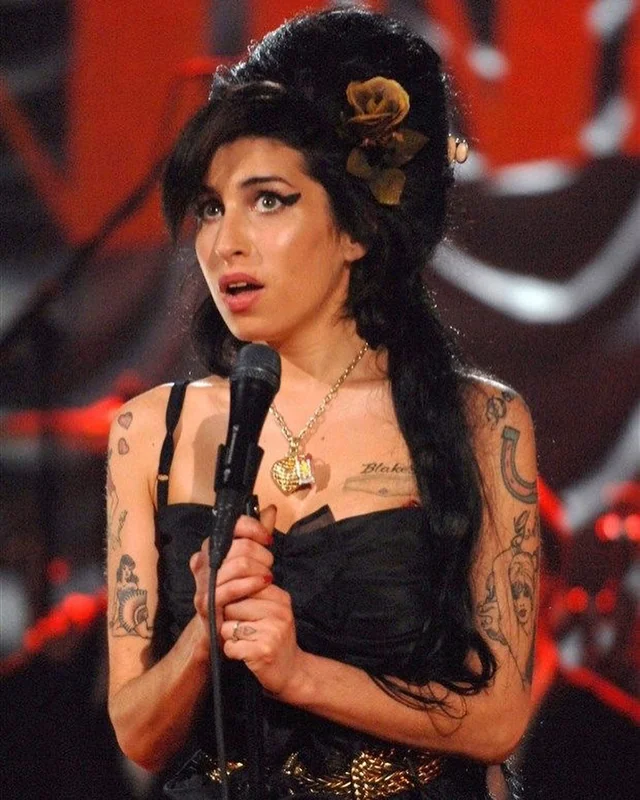

Additionally, she drew inspiration from classic artists like Aretha Franklin while creating a sound that felt modern and unique. Her music was raw, emotional, and fearless, and even years after her passing in 2011, her influence on contemporary soul and pop music remains very important.

Her last album was released after her death, curated by her producers. It contains unreleased tracks she wrote between 2002 and 2011.

### My favorite quote from her

#### **“I’d like to be remembered as someone who wasn’t satisfied with just one level of musicianship … as someone who was a pioneer.”**

#### **- Amy Winehouse**

Although she died tragically at 27, its a consolation to think that this objective was largely surpassed.

### Her albums

- Frank (2003)
- Back to Black (2006)
- Lioness: Hidden Treasures (2011, Posthumous)

# My favorites

## My favorite album

[figure not shown]

## My favorite song

#### [Love is a losing game, 2006](https://www.youtube.com/watch?v=nMO5Ko_77Hk)

[video not shown]

## My favorite lyrics

> “Though I battle blind  
> Love is a fate resigned  
> Memories mar my mind  
> Love is a fate resigned  
> Over futile odds  
> And laughed at by the gods  
> And now, the final frame  
> Love is a losing game”

> **- Amy Winehouse**

# Data Analysis

## Data Source

```r
library(ggplot2)
library(dplyr)
```

```r
setwd("/Users/fredericdenarp/Library/CloudStorage/OneDrive-UniversiteitLeiden/ORDI DOM/LUC - SECOND YEAR/Block 3 - Second Year /Data Science and AI - Joy Lee/Spotify project")
df <- read.csv("Amy Winehouse DF.csv", sep = ";", header = TRUE)
```

## Take a glance at the data frame

```r
df |> dplyr::slice_sample(n=5) |> knitr::kable(digits = 2)
```

| artist_name | album_release_year | album_name | track_name | track_number | danceability | energy | loudness | valence | speechiness | liveness | tempo | key_mode | duration_ms |
| --- | --- | --- | --- | --- | --- | --- | --- | --- | --- | --- | --- | --- | --- |
| Amy Winehouse | 2011 | Lioness: Hidden Treasures | Our Day Will Come | 1 | 0.70 | 0.63 | -6.08 | 0.64 | 0.03 | 0.35 | 98.01 | F minor | 169373 |
| Amy Winehouse | 2011 | Lioness: Hidden Treasures | Like Smoke | 5 | 0.64 | 0.87 | -3.98 | 0.34 | 0.09 | 0.18 | 97.90 | G minor | 278000 |
| Amy Winehouse | 2003 | Frank | What Is It About Men | 11 | 0.74 | 0.52 | -6.66 | 0.48 | 0.06 | 0.19 | 76.41 | B minor | 209560 |
| Amy Winehouse | 2021 | At The BBC | Monkey Man - Live On Jools Holland Hootenanny / 2006 | 7 | 0.66 | 0.87 | -6.60 | 0.93 | 0.10 | 0.97 | 135.23 | A# major | 199760 |
| Amy Winehouse | 2008 | Frank | Fool’s Gold | 7 | 0.56 | 0.56 | -5.70 | 0.21 | 0.03 | 0.23 | 82.09 | E major | 218533 |

## Cleaning up our data

I cleaned up the data frame to include only song recorded by Amy. So I removed songs she sang live, songs from the movie AMY as well as the “clean version” of the album Frank.

```r
# Remove records with the same track names
df <- df |> distinct(track_name, .keep_all = TRUE)
# Filter out track names that include "Live at" or "Live Acoustic"
df <- df |> filter(!grepl("Live at|Live Acoustic|Live", track_name, ignore.case = TRUE))
# Remove songs from the AMY movie soundtrack and from the Frank (US Clean e-Version)
df <- df |>
  filter(!album_name %in% c(
    "AMY (Original Motion Picture Soundtrack)",
    "Frank (US Clean e-Version)"
  ))
# Remove Deluxe versions of albums
df <- df |>
  filter(!grepl("Deluxe", album_name, ignore.case = TRUE))
# Change the data type of album_name from numeric into character
df$album_name <- as.character(df$album_name)
```

## Analysis of Amy Winehouse’s discography

### Amy Winehouse over the years

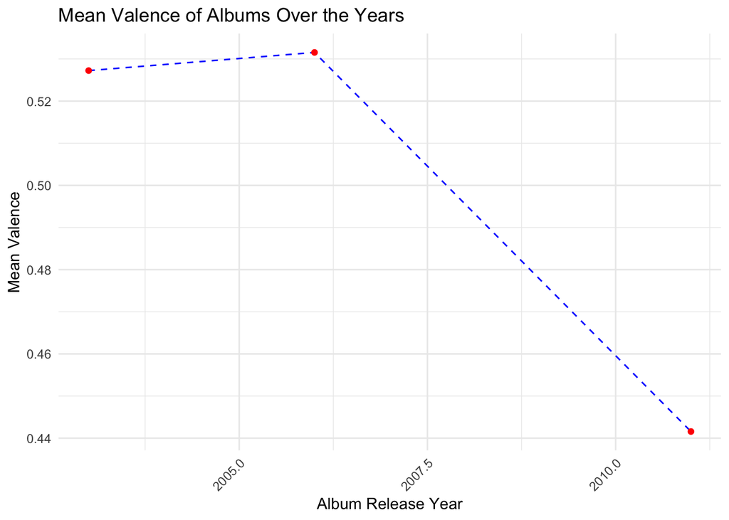

```r
library(ggplot2)
library(dplyr)

# Compute mean valence per year
df_summary <- df %>%
  group_by(album_release_year) %>%
  summarise(mean_valence = mean(valence, na.rm = TRUE))

# Plotline graph
ggplot(df_summary, aes(x = album_release_year, y = mean_valence, group = 1)) +
  geom_line(linetype = "dashed", color = "blue") +
  geom_point(color = "red") +
  labs(
    x = "Album Release Year",
    y = "Mean Valence",
    title = "Mean Valence of Albums Over the Years"
  ) +
  theme_minimal() +
  theme(axis.text.x = element_text(angle = 45, hjust = 1))
```

Her album ’Lioness: Hidden treasures” (pothumous) has a lower valence than the other two. Perhaps she decided not to release the sadder songs during her lifetime.

Let’s look at an overview of the general trend of her songs

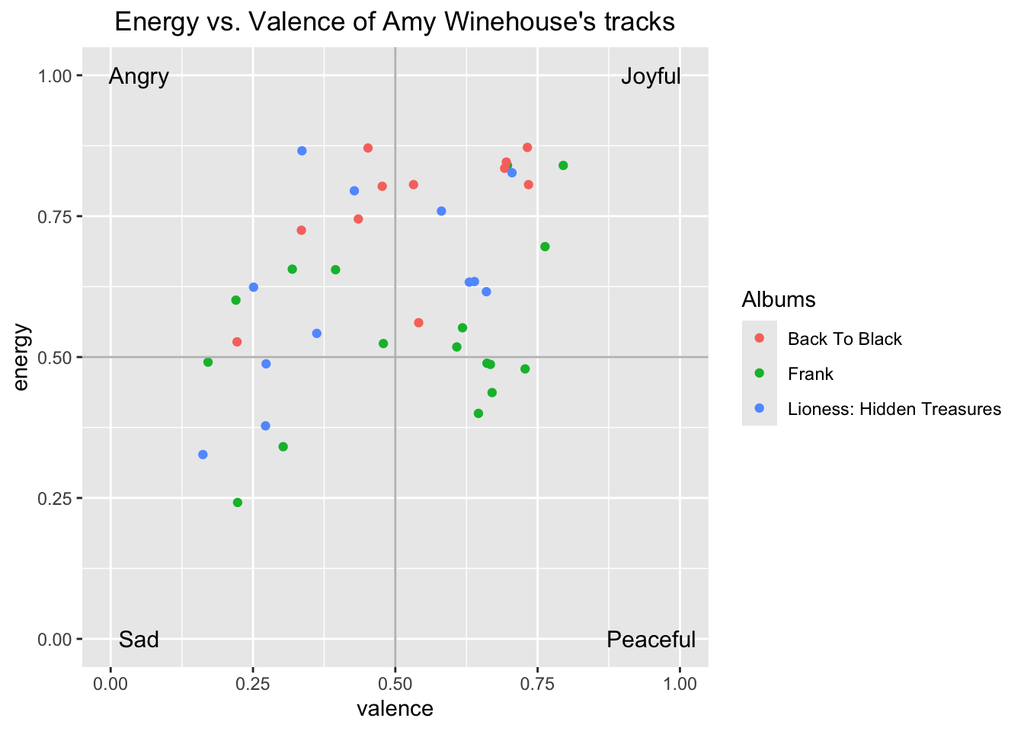

```r
ggplot(df, aes(x = valence, y = energy, color = album_name)) +
  geom_point() + #visualizing the individual tracks
  xlim(0,1) + #changing the scale to show the entire theoretical range
  ylim(0,1) +
  labs(color = "Albums", title = "Energy vs. Valence of Amy Winehouse's tracks") +
  theme(plot.title = element_text(hjust = 0.5)) + #changing and adding the labels
  geom_hline(yintercept= 0.5, color="grey") + #creating quartiles
  geom_vline(xintercept= 0.5, color="grey") +
  annotate("text", x = 0.05, y = 1, label = "Angry", size = 4) + #naming quartiles
  annotate("text", x = 0.95, y = 1, label = "Joyful", size = 4) +
  annotate("text", x = 0.05, y = 0, label = "Sad", size = 4) +
  annotate("text", x = 0.95, y = 0, label = "Peaceful", size = 4)
```

It looks like her tracks are mostly situated in in the angry and joyful categories.

### What’s her ’most joyful soundtrack?

```r
df$joy_score <- df$valence + df$energy

df[order(-df$joy_score), ][1,
   c("track_name", "album_name", "valence", "energy", "joy_score")]
```

```
  track_name album_name valence energy joy_score
8  In My Bed      Frank   0.795   0.84     1.635
```

#### In my Bed, 2003

[video not shown]

I found this surprising because it doesn’t sound particularly joyful.

### What’s her saddest soundtrack?

```r
df$sad_score <- df$valence + df$energy

df[order(df$sad_score), ][1,
   c("track_name", "album_name", "valence", "energy", "sad_score")]
```

```
                  track_name album_name valence energy sad_score
7 (There Is) No Greater Love      Frank   0.223  0.242     0.465
```

#### [(There is) No Greater Love, 2003](https://www.youtube.com/watch?v=pza_TiYCAjY)

[video not shown]

This is indeed a very sad song.

## What is special about Back to Black?

Amy Winehouse’s top 5 songs on spotify are all from the album ‘Back to Black.’ So I decided to try to analyse this album by comparing its attributes with other albums.

## First, what are the levels of valence across the albums?

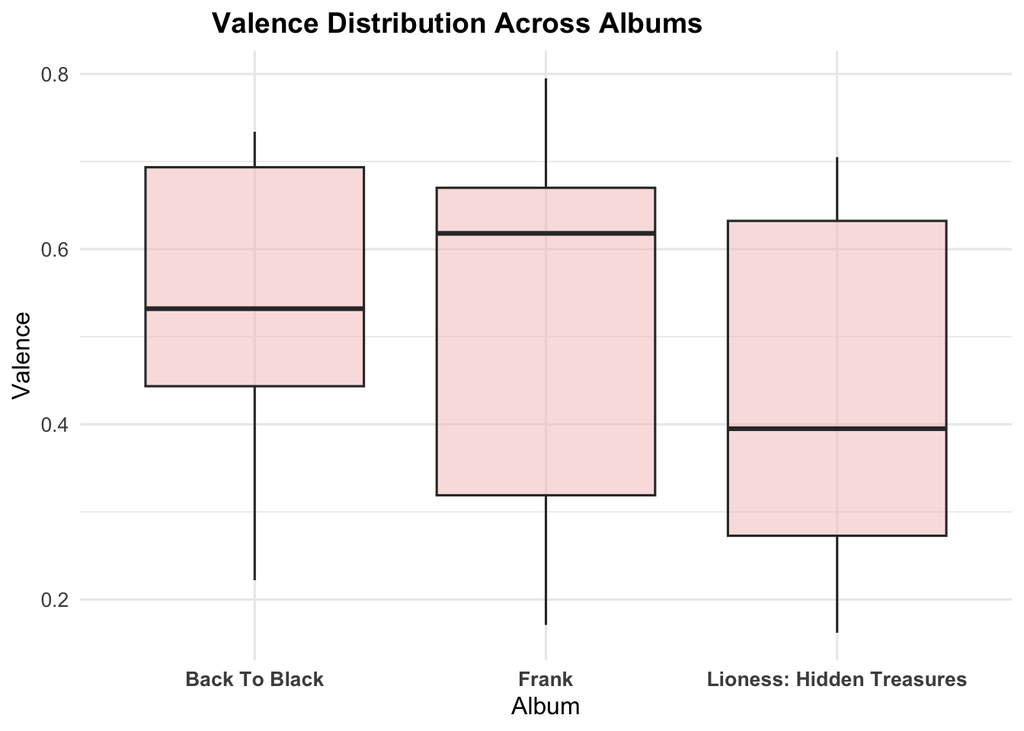

```r
library(ggplot2)

df$album_name <- as.factor(df$album_name)

ggplot(df, aes(x = album_name, y = valence, fill = album_name)) +
  geom_boxplot(alpha = 0.5) +
  labs(title = "Valence Distribution Across Albums",
       x = "Album",
       y = "Valence") +
  scale_fill_manual(values = c("#F4C2C2", "#F4C2C2", "#F4C2C2")) +
  theme_minimal(base_size = 12) +
  theme(
    plot.title = element_text(hjust = 0.3, face = "bold", size = 14),
    axis.title = element_text(size = 12),
    axis.text.x = element_text(face = "bold", size = 10),
    axis.text.y = element_text(size = 10),
    legend.position = "none"
  )
```

## What about danceability and energy across tracks?

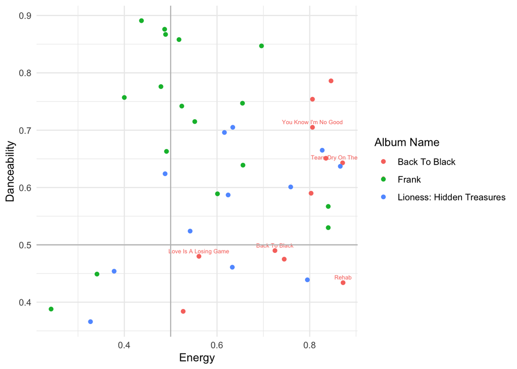

```r
subgroup <- df |>
  filter(track_name %in% c(
    "Back To Black",
    "You Know I'm No Good",
    "Tears Dry On Their Own",
    "Rehab",
    "Love Is A Losing Game"))
ggplot(df, aes(x = energy, y = danceability, color = album_name)) +
  geom_point() +
  geom_text(
    data = subgroup,
    aes(label = track_name),
    vjust = -0.8,
    size = 2
  ) +
  geom_hline(yintercept = 0.5, color = "grey") +
  geom_vline(xintercept = 0.5, color = "grey") +
  labs(x = "Energy", y = "Danceability", color = "Album Name") +
  theme_minimal()
```

The album Frank seems to feature the most “danceable” songs. However, there is no clear pattern for Back to Black, so high danceability might not be why so many people listen to her album.

## Let’s look at the Energy

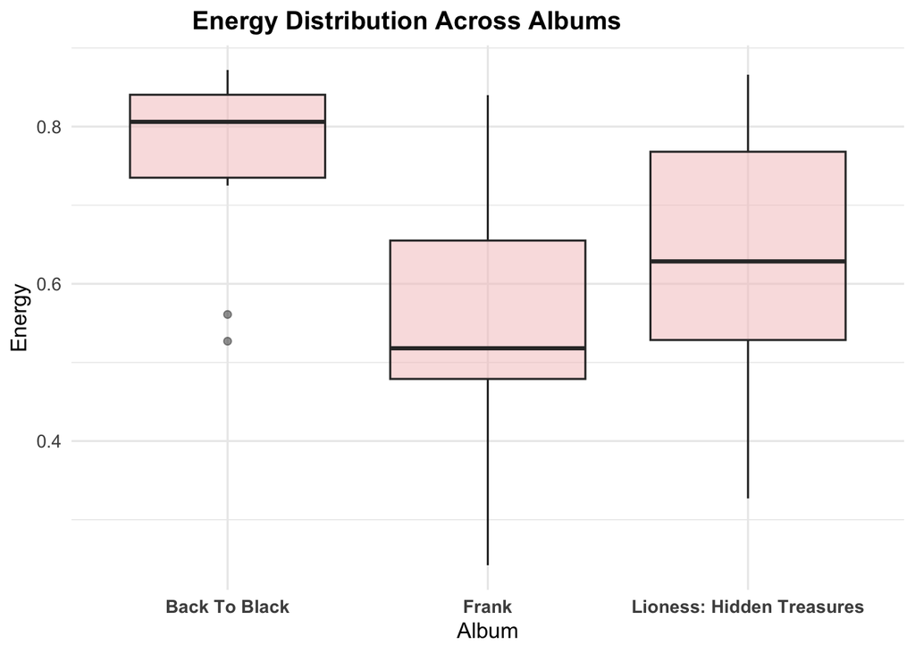

```r
library(ggplot2)

ggplot(df, aes(x = album_name, y = energy, fill = album_name)) +
  geom_boxplot(alpha = 0.5) +
  labs(title = "Energy Distribution Across Albums",
       x = "Album",
       y = "Energy") +
  scale_fill_manual(values = c("#F4C2C2", "#F4C2C2", "#F4C2C2")) +
  theme_minimal(base_size = 12) +
  theme(
    plot.title = element_text(hjust = 0.3, face = "bold", size = 14),
    axis.title = element_text(size = 12),
    axis.text.x = element_text(face = "bold", size = 10),
    axis.text.y = element_text(size = 10),
    legend.position = "none"
  )
```

Black to Black is the most energetic.

## What about the tempo?

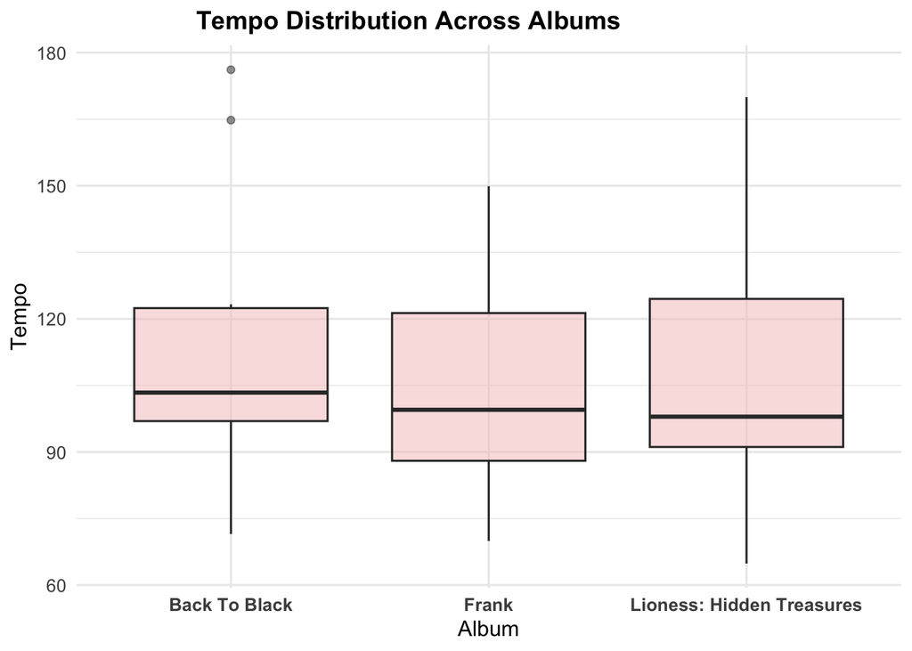

```r
library(ggplot2)

ggplot(df, aes(x = album_name, y = tempo, fill = album_name)) +
  geom_boxplot(alpha = 0.5) +
  labs(title = "Tempo Distribution Across Albums",
       x = "Album",
       y = "Tempo") +
  scale_fill_manual(values = c("#F4C2C2", "#F4C2C2", "#F4C2C2")) +
  theme_minimal(base_size = 12) +
  theme(
    plot.title = element_text(hjust = 0.3, face = "bold", size = 14),
    axis.title = element_text(size = 12),
    axis.text.x = element_text(face = "bold", size = 10),
    axis.text.y = element_text(size = 10),
    legend.position = "none"
  )
```

There is no clear pattern relative to tempo, all albums are around similar levels.

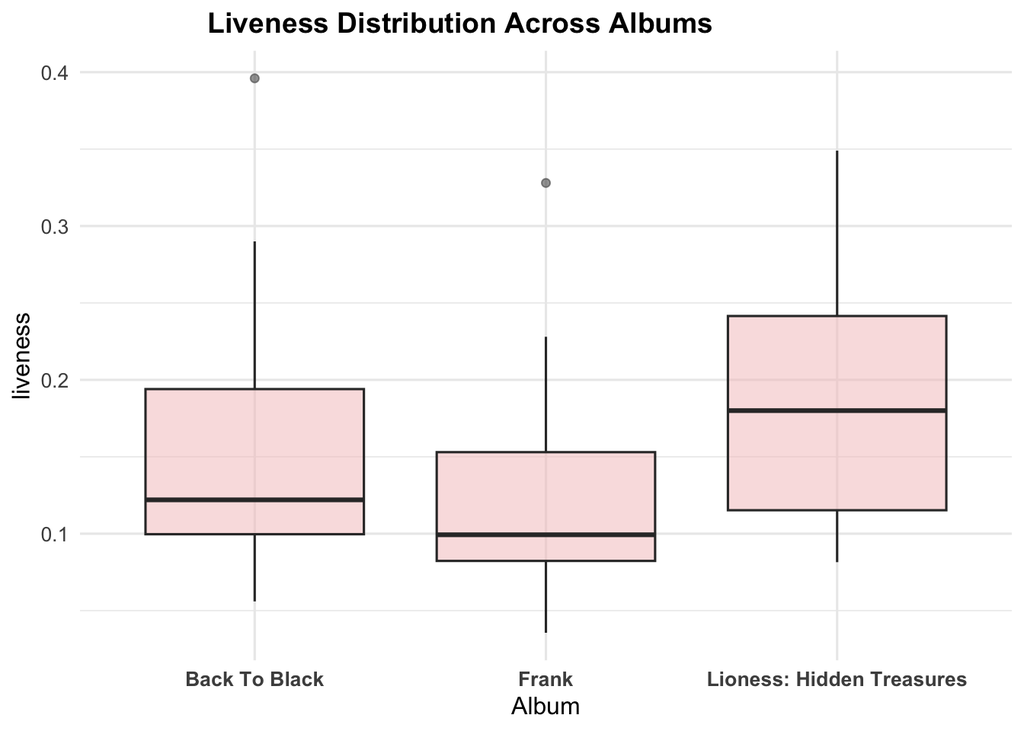

```r
library(ggplot2)

ggplot(df, aes(x = album_name, y = liveness, fill = album_name)) +
  geom_boxplot(alpha = 0.5) +
  labs(title = "Liveness Distribution Across Albums",
       x = "Album",
       y = "liveness") +
  scale_fill_manual(values = c("#F4C2C2", "#F4C2C2", "#F4C2C2")) +
  theme_minimal(base_size = 12) +
  theme(
    plot.title = element_text(hjust = 0.3, face = "bold", size = 14),
    axis.title = element_text(size = 12),
    axis.text.x = element_text(face = "bold", size = 10),
    axis.text.y = element_text(size = 10),
    legend.position = "none"
  )
```

## Why do people love the album Back to Black so much?

As I said before, Amy’s top 5 songs are all in the album ‘Back to Black.’ So I wanted to look at a new indicator, namely the level of ‘anger’ expressed in the album. But, since “anger” isn’t directly measured in the dataset, I created my own anger score using Spotify’s audio features. I based it on the idea that angry music tends to be loud, intense, and emotionally negative. So I combined energy and loudness, and subtracted valence (which measures how positive a song feels). This means songs that are high-energy, loud, and low in valence get a higher anger score.

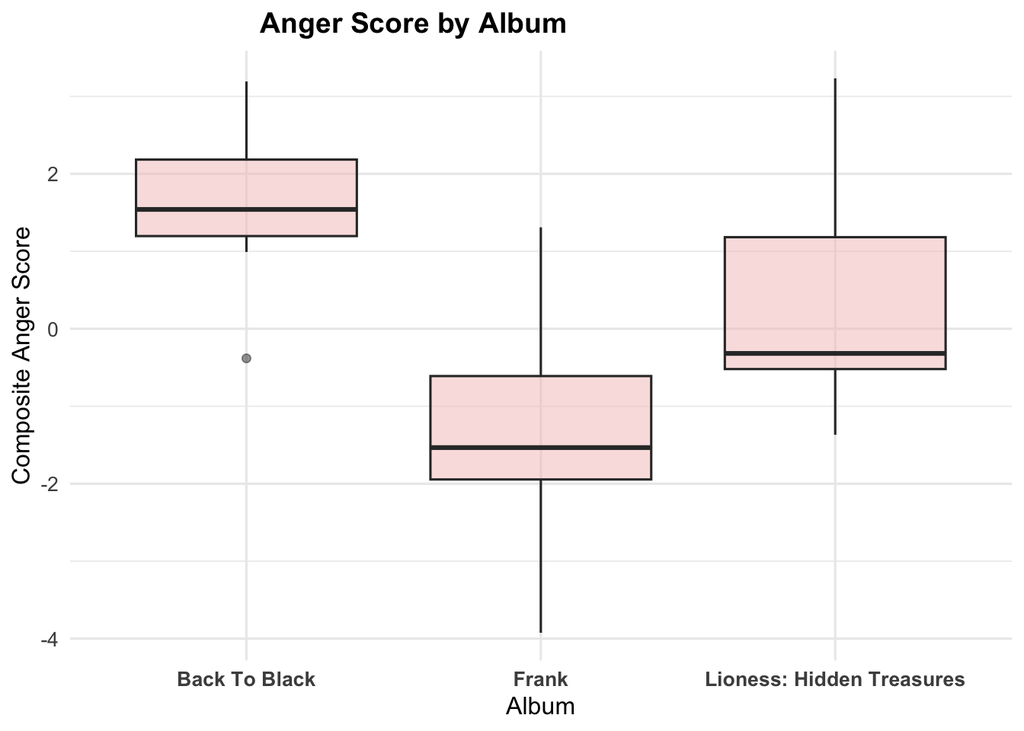

```r
library(ggplot2)

df$album_name <- as.factor(df$album_name)

# Compute anger score
df$anger_score <- scale(df$energy) +
                  scale(df$loudness) -
                  scale(df$valence)

#boxplot
ggplot(df, aes(x = album_name, y = anger_score, fill = album_name)) +
  geom_boxplot(alpha = 0.5) +
  labs(title = "Anger Score by Album",
       x = "Album",
       y = "Composite Anger Score") +
  scale_fill_manual(values = c("#F4C2C2", "#F4C2C2", "#F4C2C2")) +
  theme_minimal(base_size = 12) +
  theme(
    plot.title = element_text(hjust = 0.3, face = "bold", size = 14),
    axis.title = element_text(size = 12),
    axis.text.x = element_text(face = "bold", size = 10),
    axis.text.y = element_text(size = 10),
    legend.position = "none"
  )
```

“Back to Black” seems to be her angriest album. This makes sense because Back to Black was written after her break-up with her ex-boyfriend, which ended in not so great conditions because he cheated on her with his ex-girlfriend. In fact, most songs bring up the subject of her heartbreak, and of her feeling lonely and resentful.

### Is there a pattern of angriness in Back to Black?

Then, I wanted to look at whether there was a pattern in anger intensity in her album according to the track number. So I made a line graph showing the anger score based on the track number.

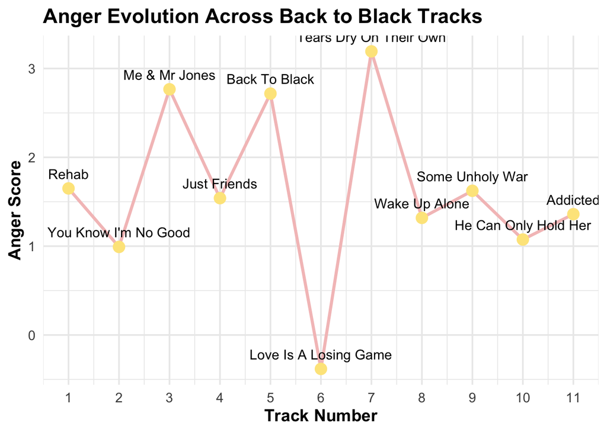

```r
library(ggplot2)

# Filter Back to Black
btb <- df[df$album_name == "Back To Black", ]

ggplot(btb, aes(x = track_number, y = anger_score)) +
  geom_line(color = "#F4C2C2", size = 1.2) +
  geom_point(color = "#FDE68A", size = 4) +
  geom_text(aes(label = track_name),
            vjust = -1, hjust = 0.5, size = 4) +
  scale_x_continuous(breaks = btb$track_number) +
  labs(title = "Anger Evolution Across Back to Black Tracks",
       x = "Track Number",
       y = "Anger Score") +
  theme_minimal(base_size = 14) +
  theme(
    plot.title = element_text(face = "bold"),
    axis.title = element_text(face = "bold")
  )
```

We can conclude that there isn’t any a pattern.

However, the graph gives us her most angry song. Lets have a look at it.

Do you think this song is ‘angrier’ than the track Back to Black ?

## Let’s listen to them! What do you think?

#### [Tears Dry on Their Own, 2006](https://www.youtube.com/watch?v=3jHYzJUoGB0&list=RD3jHYzJUoGB0&start_radio=1)

[video not shown]

#### [Back To Black, 2006](https://www.youtube.com/watch?v=4Q4Gy2Z7xZ0&list=RD4Q4Gy2Z7xZ0&start_radio=1)

[video not shown]

### Conclusion

From this analysis we can deduce that:

- Back to Black dominates: it contains her top 5 most streamed tracks and is characterized by both high energy and high anger scores, reflecting the personal heartbreak she experienced at the time.
- The appeal of *Back to Black* seems to come from the combination of musically catchy, upbeat production with raw, confessional lyrics. Something that’s interesting is that according to the dataset’s indicators her songs have rather ‘happy’ attributes. But in fact, when looking at the lyrics the songs convey dark emotions creating a compelling emotional tension. And that is the reason I think why I, as many others, love Back to Black.